# Analysis of the Heart Transplant Data

Nathan DeBenedictis

December 2025

## Introduction

Survival analysis is a statistical framework used to study the time until the occurrence of an event of interest, such as death or disease progression. It is particularly well suited for clinical data, where follow-up times vary across individuals and censoring is common. In this project, we analyze data from the Stanford Heart Transplant Study, which followed patients with severe heart disease who were evaluated for placement on a heart transplant waiting list.

Patients entered the study upon acceptance into the transplant program and were followed until death or the end of the study period. During follow-up, some patients received a donor heart, while others did not. As a result, transplant status may change over time, making it necessary to treat transplantation as a time-dependent covariate rather than a fixed characteristic. The primary outcome of interest is survival time, measured from program entry until death or censoring.

The goal of this analysis is to explore survival patterns in this cohort and to quantify the effects of transplantation and key baseline covariates, such as age and prior surgery, on mortality risk using appropriate survival modeling techniques.

## Data Description

Key variables include:

start: beginning of the observation interval

stop: end of the observation interval

event: indicator of death during the interval (1 = death)

age: age at acceptance into the program, centered at 48 years

year: year of acceptance, measured in years after November 1, 1967

surgery: indicator of prior heart surgery

transplant: time-dependent indicator of whether a transplant occurred during the interval

id: patient identifier

Survival times are right-censored for patients who were alive at the end of follow-up. The primary focus of the analysis is to assess how transplantation, age, and prior surgery are associated with survival outcomes.

```
##      start             stop            event            age
##  Min.   :  0.00   Min.   :   1.0   Min.   :0.000   Min.   :-39.2142
##  1st Qu.:  0.00   1st Qu.:  17.0   1st Qu.:0.000   1st Qu.: -6.6468
##  Median :  0.00   Median :  45.5   Median :0.000   Median : -0.1136
##  Mean   : 15.51   Mean   : 201.3   Mean   :0.436   Mean   : -2.4840
##  3rd Qu.: 18.25   3rd Qu.: 181.5   3rd Qu.:1.000   3rd Qu.:  4.0459
##  Max.   :310.00   Max.   :1800.0   Max.   :1.000   Max.   : 16.4079
##       year             surgery       transplant       id
##  Min.   :-0.04928   Min.   :0.0000   0:103      Min.   :  1.00
##  1st Qu.: 1.66051   1st Qu.:0.0000   1: 69      1st Qu.: 28.00
##  Median : 3.75086   Median :0.0000              Median : 53.50
##  Mean   : 3.45329   Mean   :0.1686              Mean   : 53.06
##  3rd Qu.: 5.03491   3rd Qu.:0.0000              3rd Qu.: 78.25
##  Max.   : 6.47228   Max.   :1.0000              Max.   :103.00
```

## 3.2 Exploratory Data Analysis

Next, we examine relationships between covariates of interest and survival time in the heart transplant cohort. Because the heart dataset uses a start–stop (counting process) format with potentially multiple rows per patient, we construct a patient-level dataset (one row per patient) for exploratory plots of total survival time. We focus on clinically meaningful baseline covariates such as transplant status (descriptive grouping), age, and prior surgery, which are hypothesized to influence survival outcomes.

[figure not shown]

## 3.3 Survival Analysis

[figure not shown]

```
## [1] "Survival Probabilities and 95% CI at 1000 Days for Age Group:"
```

```
##     Group Time Survival_Prob  Lower_CI  Upper_CI
## 1 Overall 1000     0.2050814 0.1279181 0.3287912
```

```
## [1] "Survival Probabilities and 95% CI at 1000 Days for Transplant Status:"
```

```
##     Group Time Survival_Prob  Lower_CI  Upper_CI
## 1 Overall 1000    0.06573296 0.0172904 0.2498972
```

```
## [1] "Survival Probabilities and 95% CI at 1000 Days for Prior Surgery:"
```

```
##                Group Time Survival_Prob  Lower_CI  Upper_CI
## 1 surgery=No Surgery 1000     0.1928979 0.1140679 0.3262057
## 2    surgery=Surgery 1000     0.3115385 0.1295973 0.7489062
```

The survival probabilities at 1000 days, along with their 95% confidence intervals, provide insight into differences in survival across key patient characteristics in the heart transplant cohort.

For the overall cohort, the estimated survival probability at 1000 days is approximately 20.5%, with a 95% confidence interval of [12.8%, 32.9%], indicating that fewer than one-quarter of patients survive beyond this time point. This reflects the severity of disease in this population and the substantial mortality risk during follow-up.

Differences are also observed when stratifying by prior surgery status. Patients without prior surgery have a survival probability of approximately 19.3% at 1000 days (95% CI: [11.4%, 32.6%]), whereas patients with a history of prior surgery exhibit a higher survival probability of approximately 31.2% (95% CI: [13.0%, 74.9%]). Although the confidence interval for the surgery group is wide, likely due to fewer observations at later times, the point estimates suggest improved survival among patients who underwent prior surgery.

```
## [1] "Log-Rank Test for Prior Surgery:"
```

```
## Call:
## survdiff(formula = Surv(surv, event) ~ surgery, data = heart_pat)
##
##                     N Observed Expected (O-E)^2/E (O-E)^2/V
## surgery=No Surgery 87       66     58.6     0.938      4.44
## surgery=Surgery    16        9     16.4     3.348      4.44
##
##  Chisq= 4.4  on 1 degrees of freedom, p= 0.04
```

The log-rank test was used to compare survival behavior across prior surgery status, and the results reveal a statistically significant difference in survival outcomes between the two groups. Among patients with no prior surgery (N = 87), there were 66 observed deaths, compared to 9 observed deaths among patients who had undergone prior surgery (N = 16). These observed numbers differ from the expected deaths under the null hypothesis of equal survival distributions, with the no-surgery group experiencing more deaths than expected (66 observed vs. 58.6 expected) and the surgery group experiencing fewer deaths than expected (9 observed vs. 16.4 expected).

This discrepancy between observed and expected events is reflected in the log-rank test statistic (Chisq = 4.4) with 1 degree of freedom, yielding a p-value of 0.04. As a result, the null hypothesis of equal survival distributions between the surgery groups is rejected at the 5% significance level. These results indicate that patients with a history of prior surgery tend to have better survival outcomes compared to those without prior surgery. The Kaplan–Meier survival curves are consistent with this finding, showing higher survival probabilities over time for patients who underwent prior surgery, thereby supporting the validity of the log-rank comparison in this context.

```
## Call:
## coxph(formula = Surv(start, stop, event) ~ transplant + age +
##     surgery, data = heart)
##
##   n= 172, number of events= 75
##
##                 coef exp(coef) se(coef)      z Pr(>|z|)
## transplant1  0.01610   1.01623  0.30859  0.052   0.9584
## age          0.03054   1.03101  0.01389  2.198   0.0279 *
## surgery     -0.77333   0.46147  0.35967 -2.150   0.0315 *
## ---
## Signif. codes:  0 '***' 0.001 '**' 0.01 '*' 0.05 '.' 0.1 ' ' 1
##
##             exp(coef) exp(-coef) lower .95 upper .95
## transplant1    1.0162     0.9840     0.555    1.8606
## age            1.0310     0.9699     1.003    1.0595
## surgery        0.4615     2.1670     0.228    0.9339
##
## Concordance= 0.6  (se = 0.036 )
## Likelihood ratio test= 10.72  on 3 df,   p=0.01
## Wald test            = 9.68  on 3 df,   p=0.02
## Score (logrank) test = 10  on 3 df,   p=0.02
```

```
## Hazard Ratio (Age 60 vs Age 50): 1.357118
```

```
## 95% CI for HR: [ 1.033617 ,  1.781867 ]
```

The Cox proportional hazards model included transplant status, age, and prior surgery, with no transplant and no prior surgery serving as reference categories. Transplant status was not significantly associated with mortality (HR = 1.02, 95% CI: [0.56, 1.86], p = 0.96), indicating no detectable independent effect after adjustment.

Prior surgery was significantly protective, with a hazard ratio of 0.46 (95% CI: [0.23, 0.93], p = 0.03), corresponding to a 53.9% reduction in mortality risk compared to patients without prior surgery.

Age was a significant predictor of survival (HR = 1.03 per year, 95% CI: [1.003, 1.059], p = 0.028), implying a 3.1% increase in hazard for each additional year of age. Comparing a 60-year-old to a 50-year-old patient yields a hazard ratio of 1.36 (95% CI: [1.03, 1.78]), indicating a 35.7% higher risk of death for the older individual.

The model showed moderate discrimination (concordance = 0.60) and was statistically significant overall, as indicated by the likelihood ratio test (χ² = 10.72, p = 0.01), Wald test (p = 0.02), and score test (p = 0.02). These results identify age and prior surgery as key predictors of survival in this cohort, while transplant status does not show a significant independent association in this model.

```
## Likelihood Ratio Test for H0: beta_age = 0:
```

```
## Analysis of Deviance Table
##  Cox model: response is  Surv(start, stop, event)
##  Model 1: ~ transplant + surgery
##  Model 2: ~ transplant + age + surgery
##    loglik  Chisq Df Pr(>|Chi|)
## 1 -295.44
## 2 -292.76 5.3563  1    0.02065 *
## ---
## Signif. codes:  0 '***' 0.001 '**' 0.01 '*' 0.05 '.' 0.1 ' ' 1
```

The increase in log-likelihood from −295.44 in the reduced model to −292.76 in the full model indicates an improved model fit when age is included. Statistically, this improvement is meaningful and suggests that age explains additional variation in survival times beyond that captured by the other covariates.

Overall, the Cox proportional hazards model indicates that age is an important predictor of survival in the heart transplant data, even when accounting for transplant and surgical effects. Including age improves the explanatory power of the model and supports its role as a relevant risk factor in assessing patient survival.

```
## Call:
## coxph(formula = Surv(start, stop, event) ~ transplant + surgery +
##     strata(agegrp), data = heart)
##
##   n= 172, number of events= 75
##
##                coef exp(coef) se(coef)      z Pr(>|z|)
## transplant1  0.1583    1.1716   0.2969  0.533   0.5938
## surgery     -0.7492    0.4727   0.3596 -2.083   0.0372 *
## ---
## Signif. codes:  0 '***' 0.001 '**' 0.01 '*' 0.05 '.' 0.1 ' ' 1
##
##             exp(coef) exp(-coef) lower .95 upper .95
## transplant1    1.1716     0.8536    0.6547    2.0964
## surgery        0.4727     2.1153    0.2336    0.9566
##
## Concordance= 0.563  (se = 0.031 )
## Likelihood ratio test= 5.36  on 2 df,   p=0.07
## Wald test            = 4.54  on 2 df,   p=0.1
## Score (logrank) test = 4.73  on 2 df,   p=0.09
```

```
## Call:
## coxph(formula = Surv(start, stop, event) ~ transplant + surgery +
##     agegrp, data = heart)
##
##   n= 172, number of events= 75
##
##                coef exp(coef) se(coef)      z Pr(>|z|)
## transplant1  0.1583    1.1716   0.2969  0.533   0.5938
## surgery     -0.7492    0.4727   0.3596 -2.083   0.0372 *
## agegrp60+        NA        NA   0.0000     NA       NA
## ---
## Signif. codes:  0 '***' 0.001 '**' 0.01 '*' 0.05 '.' 0.1 ' ' 1
##
##             exp(coef) exp(-coef) lower .95 upper .95
## transplant1    1.1716     0.8536    0.6547    2.0964
## surgery        0.4727     2.1153    0.2336    0.9566
## agegrp60+          NA         NA        NA        NA
##
## Concordance= 0.563  (se = 0.031 )
## Likelihood ratio test= 5.36  on 2 df,   p=0.07
## Wald test            = 4.54  on 2 df,   p=0.1
## Score (logrank) test = 4.73  on 2 df,   p=0.09
```

```
## AIC for Stratified Model: 594.8803
```

```
## AIC for Additive Model: 594.8803
```

```
## AIC for Interaction Model: 591.9125
```

```
## Analysis of Deviance Table
##  Cox model: response is  Surv(start, stop, event)
##  Model 1: ~ transplant + surgery + agegrp
##  Model 2: ~ transplant * age + surgery
##    loglik  Chisq Df Pr(>|Chi|)
## 1 -295.44
## 2 -291.96 6.9678  2    0.03069 *
## ---
## Signif. codes:  0 '***' 0.001 '**' 0.01 '*' 0.05 '.' 0.1 ' ' 1
```

The interaction model, which allowed the effect of transplant to vary with age by introducing age as a continuous effect modifier, yielded a lower AIC value of 591.91, suggesting an improved fit relative to the additive and stratified specifications. A likelihood ratio test comparing the additive and interaction models produced a chi-squared statistic of 6.97 with 2 degrees of freedom (p = 0.031), indicating that allowing age-dependent transplant effects significantly improves model fit. This result provides evidence that the relationship between transplant and survival is not constant across ages and that age may modify the effect of transplant on mortality risk.

In summary, while the stratified and additive models provided similar fits to the data, the additive model was limited by the non-estimability of the age-group coefficient. The interaction model demonstrated a statistically significant improvement in fit, suggesting meaningful age-related heterogeneity in covariate effects. Nevertheless, across all specifications, surgery consistently emerged as a significant protective factor, whereas the main effect of transplant alone did not appear to substantially influence survival. These findings highlight the importance of carefully modeling age in the heart dataset and suggest that simple additive age-group effects may be insufficient to capture its role in survival dynamics.

```
##             chisq df    p
## transplant 0.1283  1 0.72
## surgery    0.0968  1 0.76
## age        0.8954  1 0.34
## GLOBAL     1.3793  3 0.71
```

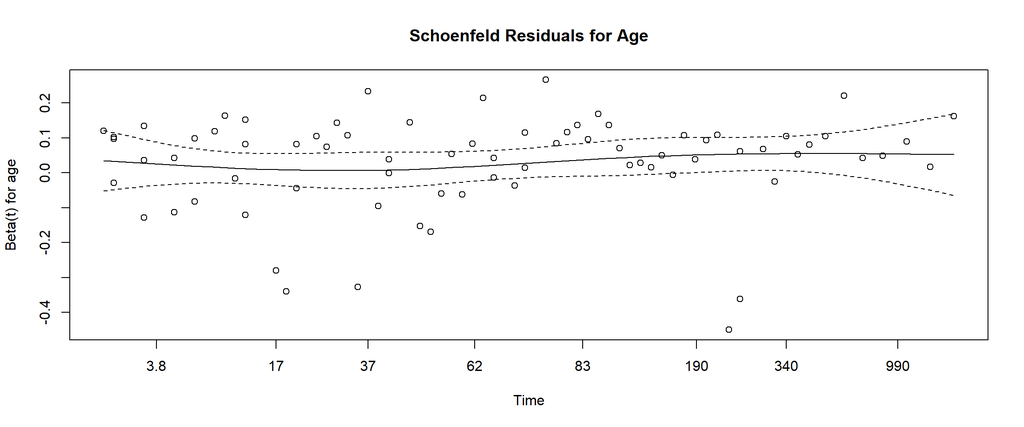

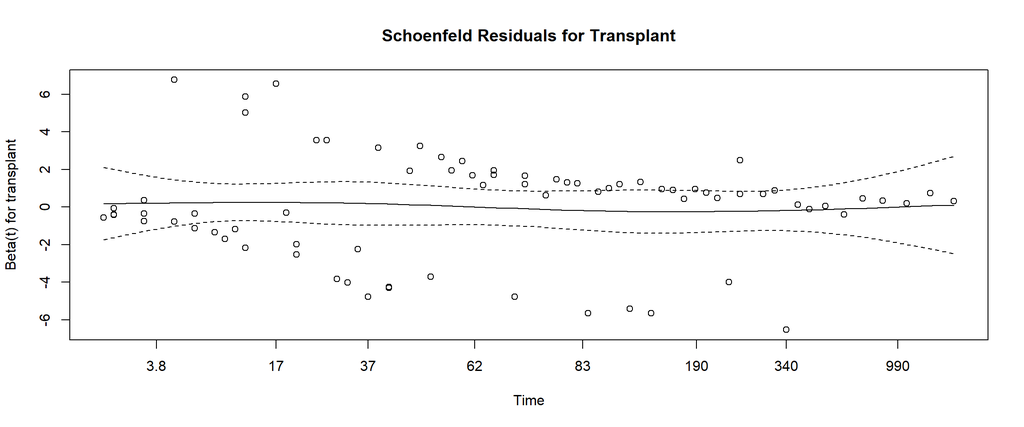

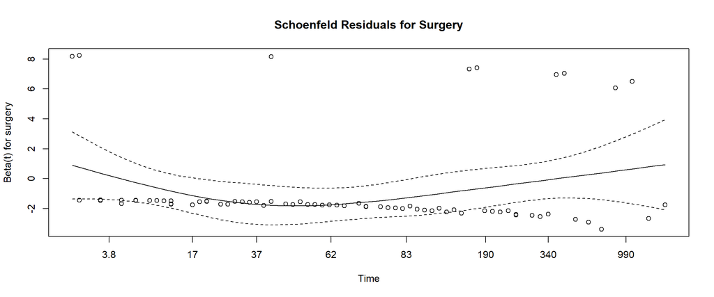

The Schoenfeld residuals plots for age, transplant, and surgery assess the proportional hazards assumption for the Cox model fitted to the heart dataset. If the assumption holds, residuals should show no systematic trend over time and fluctuate randomly around zero.

For age, the residuals are randomly scattered around zero with a relatively flat smoothed curve, indicating no time‐dependent pattern. This is supported by the non-significant Schoenfeld test (χ² = 0.90, p = 0.34), suggesting the proportional hazards assumption is reasonable for age.

Similarly, the residuals for transplant show no systematic deviation over time, and the smoothed trend remains flat, consistent with the non-significant test result (χ² = 0.13, p = 0.72).

Finally, the global test yields χ² = 1.38 with 3 degrees of freedom (p = 0.71), providing overall support for the proportional hazards assumption across all covariates.

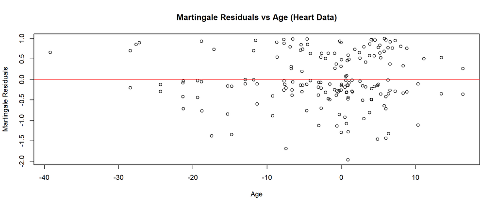

The Martingale residuals, plotted against age, assess the linearity of age’s relationship with the log hazard in the heart dataset. Ideally, these residuals should be evenly distributed around zero with no systematic pattern. In this plot, the residuals are centered around zero but show noticeable skewness and increased dispersion at higher values of age, suggesting departures from linearity. This pattern indicates that the effect of age on the log hazard may not be strictly linear, and that a transformation of age, such as the inclusion of a quadratic term or a spline, could potentially improve model fit.

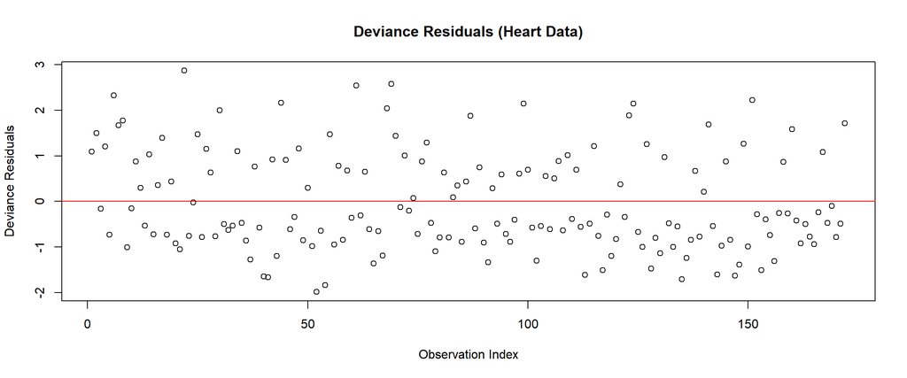

```
## Potential Outliers:
##
```

The deviance residuals plot visualizes how well the Cox proportional hazards model fits the heart dataset and helps identify potential outliers. Deviance residuals measure each observation’s contribution to the partial likelihood, with larger absolute values indicating greater departures from the model’s predicted risk.

In this plot, the residuals are largely centered around zero and display a roughly symmetric dispersion across observation indices, suggesting that the model provides an adequate fit for the majority of observations. Importantly, no deviance residuals exceed the ±3 threshold, indicating that there are no clear outliers or highly influential observations. Overall, this pattern supports the adequacy of the fitted Cox model and suggests that no individual observations unduly influence the results.

[figure not shown]

## Conclusion

In this project, a Cox proportional hazards model was used to analyze survival in the heart dataset while accounting for time‐dependent transplant status and key clinical covariates. Diagnostic checks using Schoenfeld, Martingale, and deviance residuals provided no evidence of violations of the proportional hazards assumption, influential outliers, or severe model misspecification. Although age showed signs of possible nonlinearity, the overall model fit remained adequate and stable across multiple specifications. Collectively, these results support the validity of the Cox modeling approach for this dataset and reinforce the importance of careful diagnostic evaluation in survival analysis.